# People in Networks_Measures of Centrality

Tom Leppard

2025-04-08

# People in Networks

One way to analyse a social network is to analyse the people in those networks. In general terms,we can report on individuals based on the structural position they hold within a network. The concept and various measures of centrality allows us to do so. Ultimately, as the scientist, you can tell stories about the individuals in your network based on how central of peripheral they are in the group. In other words, measures of centrality tell stories about the individuals in your network.

I encourage you to think about these measures in terms of an individuals prominence and influence over the network. In this chapter, we will be using four measures, degree centrality, betweenness centrality, closeness centrality, and constraint. First, let’s go through these one-by-one showing how to measure these in igraph. I won’t go too deep into the maths behind the algorithms, but will focus more on substantively what it means. Then, I will show you how to construct a data frame with all of this information so you can then use these to run further analysis (i.e. perhaps regressing centrality on career success). You may have multiple years worth of networks and could create line graphs of centrality for each node over time to see their personal change overtime.

Before we begin, let’s bring in the Grime data we have been using so far. We know by now we need to remove self loops in this edgelist.

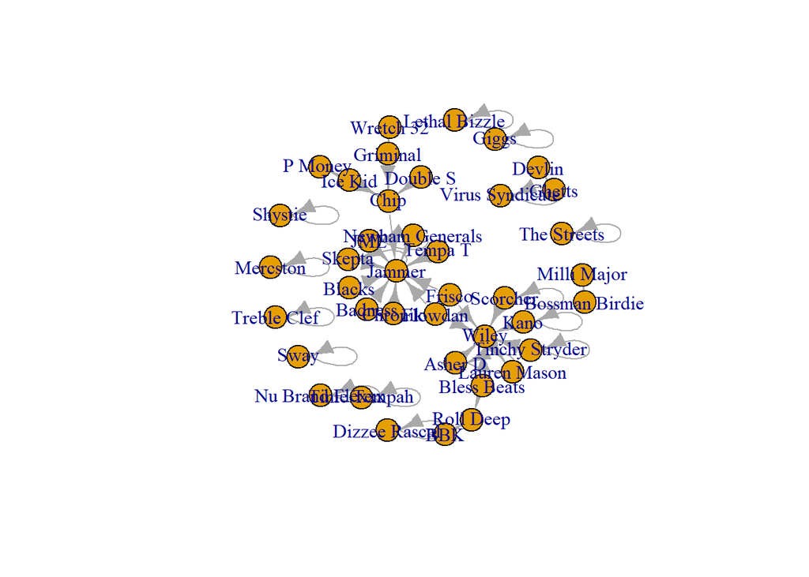

```r
library(igraph)

grime_edge_list <- read.csv(file.choose(), header = TRUE)

grime_08 <- graph_from_data_frame(d= grime_edge_list, directed = TRUE)
plot(grime_08)
```

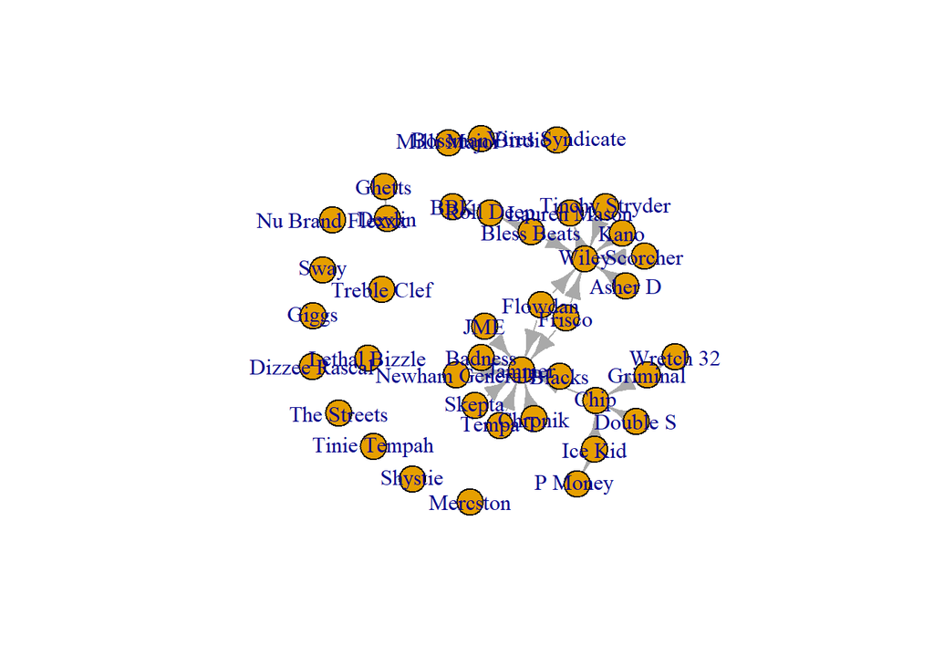

```r
grime_08_clean <- delete.edges(grime_08, E(grime_08)[which_loop(grime_08)])

plot(grime_08_clean)
```

## Measures of Centrality

You may be interested in finding out who are some prominent individuals in your network. When I say prominent, I really mean those what are “well connected” or perhaps “popular”. Someone who is very prominent in the network is likely positioned very central compared to others.

### Degree Centrality and Strength

Degree centrality is simply a count of the number of ties that a node has with others in the network. Put simply, it is a count of how many neighbours any given node has.

```r
degree(grime_08_clean)
```

```
##         Asher D   Dizzee Rascal   Lethal Bizzle        Scorcher     Bless Beats
##               1               0               0               1               2
##         Flowdan  Tinchy Stryder          Frisco            Kano     Treble Clef
##               2               1               2               1               0
##         Shystie          Blacks         Badness         Chronik         Tempa T
##               0               1               1               1               1
## Newham Generals          Skepta             JME            Chip             BBK
##               1               1               1               4               1
## Virus Syndicate          Ghetts        Mercston        Double S        Griminal
##               0               1               0               1               3
##         Ice Kid Nu Brand Flexxx       Wretch 32           Wiley  Bossman Birdie
##               2               0               2               8               1
##     The Streets            Sway    Tinie Tempah           Giggs          Jammer
##               0               0               0               0              10
##       Roll Deep          Devlin        P Money     Lauren Mason     Milli Major
##               2               1               1               1               1
```

There is a variation of degree centrality called strength(), which accounts for the weighted nature of the edges. Instead of just counting the number of neighbours, it sums the weights of the connections to each neighbor, reflecting both the number of connections and their strength (or whatever the edge weight represents).

```r
strength(grime_08_clean)
```

```
##         Asher D   Dizzee Rascal   Lethal Bizzle        Scorcher     Bless Beats
##               1               0               0               1               2
##         Flowdan  Tinchy Stryder          Frisco            Kano     Treble Clef
##               2               1               2               1               0
##         Shystie          Blacks         Badness         Chronik         Tempa T
##               0               1               1               1               1
## Newham Generals          Skepta             JME            Chip             BBK
##               1               1               1               4               1
## Virus Syndicate          Ghetts        Mercston        Double S        Griminal
##               0               1               0               1               3
##         Ice Kid Nu Brand Flexxx       Wretch 32           Wiley  Bossman Birdie
##               2               0               2               8               1
##     The Streets            Sway    Tinie Tempah           Giggs          Jammer
##               0               0               0               0              10
##       Roll Deep          Devlin        P Money     Lauren Mason     Milli Major
##               2               1               1               1               1
```

So, we see that Wiley and Jammer are very popular in this network. However, since this is a directed network, there is even more that we can tease out from this in terms of their outgoing and incoming connections. Put simply, we can get the individual’s strength (i.e. the number of connections and edge weight). We do this by using the ‘mode =’ argument from the strength() function. “in” takes the incoming ties and “out” gets the outgoing ties.

```r
strength(grime_08_clean, mode = "in", loops = FALSE)
```

```
##         Asher D   Dizzee Rascal   Lethal Bizzle        Scorcher     Bless Beats
##               0               0               0               0               0
##         Flowdan  Tinchy Stryder          Frisco            Kano     Treble Clef
##               0               0               0               0               0
##         Shystie          Blacks         Badness         Chronik         Tempa T
##               0               0               0               0               0
## Newham Generals          Skepta             JME            Chip             BBK
##               0               0               0               3               0
## Virus Syndicate          Ghetts        Mercston        Double S        Griminal
##               0               0               0               0               1
##         Ice Kid Nu Brand Flexxx       Wretch 32           Wiley  Bossman Birdie
##               0               0               1               7               0
##     The Streets            Sway    Tinie Tempah           Giggs          Jammer
##               0               0               0               0              10
##       Roll Deep          Devlin        P Money     Lauren Mason     Milli Major
##               2               1               1               1               1
```

```r
strength(grime_08_clean, mode = "out", loops = FALSE)
```

```
##         Asher D   Dizzee Rascal   Lethal Bizzle        Scorcher     Bless Beats
##               1               0               0               1               2
##         Flowdan  Tinchy Stryder          Frisco            Kano     Treble Clef
##               2               1               2               1               0
##         Shystie          Blacks         Badness         Chronik         Tempa T
##               0               1               1               1               1
## Newham Generals          Skepta             JME            Chip             BBK
##               1               1               1               1               1
## Virus Syndicate          Ghetts        Mercston        Double S        Griminal
##               0               1               0               1               2
##         Ice Kid Nu Brand Flexxx       Wretch 32           Wiley  Bossman Birdie
##               2               0               1               1               1
##     The Streets            Sway    Tinie Tempah           Giggs          Jammer
##               0               0               0               0               0
##       Roll Deep          Devlin        P Money     Lauren Mason     Milli Major
##               0               0               0               0               0
```

### Closeness Centrality

Another measurement of centrality that captures the prominence of a node is closeness centrality. The closeness centrality measure uses the average length of the shortest path from one node to all other nodes in the network. Simply, it measures how close a node is to others in the network. A node with a high closeness centrality is considered more prominent in the network because they can reach all others in the network quickly.

```r
closeness(grime_08_clean)
```

```
##         Asher D   Dizzee Rascal   Lethal Bizzle        Scorcher     Bless Beats
##       0.3333333             NaN             NaN       0.3333333       0.2500000
##         Flowdan  Tinchy Stryder          Frisco            Kano     Treble Clef
##       0.2500000       0.3333333       0.2500000       0.3333333             NaN
##         Shystie          Blacks         Badness         Chronik         Tempa T
##             NaN       1.0000000       1.0000000       1.0000000       1.0000000
## Newham Generals          Skepta             JME            Chip             BBK
##       1.0000000       1.0000000       1.0000000       1.0000000       1.0000000
## Virus Syndicate          Ghetts        Mercston        Double S        Griminal
##             NaN       1.0000000             NaN       0.3333333       0.2500000
##         Ice Kid Nu Brand Flexxx       Wretch 32           Wiley  Bossman Birdie
##       0.2500000             NaN       0.1666667       1.0000000       1.0000000
##     The Streets            Sway    Tinie Tempah           Giggs          Jammer
##             NaN             NaN             NaN             NaN             NaN
##       Roll Deep          Devlin        P Money     Lauren Mason     Milli Major
##             NaN             NaN             NaN             NaN             NaN
```

Some of you noted that certain nodes had a score of 1 - like Tempa T. If you look at Tempa T, this node appears to be connected to a big hub of the network (Jammer’s). However, pay attention to the direction of the ties. Jammer is as far as Tempa T can get. So, the maths for his closeness score is 1 step. 1/1 = 1.

Betweenness centrality measures the number of times an individual node lies on the shortest path (geodesic) between any two other nodes in the network. A geodesic is the shortest possible path connecting two nodes. Imagine a network as a set of people connected by relationships, where you are trying to travel from one person to another. The shortest path represents the quickest way to get from one node to another in the network. Betweenness centrality counts how often a specific node appears as a part of these shortest paths, reflecting its role in connecting different parts of the network.

For this measure, whether the network is directed is important. Consider ties as roads: if there are two lanes (one for going and one for returning), information can flow in both directions. However, if there is only a one-way road, information can only travel in one direction. In a directed network, a node may appear on the geodesic, but if it only has outgoing connections, it might not have much influence on others, as it cannot receive information from other nodes.

```r
betweenness(grime_08_clean)
```

```
##         Asher D   Dizzee Rascal   Lethal Bizzle        Scorcher     Bless Beats
##               0               0               0               0               0
##         Flowdan  Tinchy Stryder          Frisco            Kano     Treble Clef
##               0               0               0               0               0
##         Shystie          Blacks         Badness         Chronik         Tempa T
##               0               0               0               0               0
## Newham Generals          Skepta             JME            Chip             BBK
##               0               0               0               4               0
## Virus Syndicate          Ghetts        Mercston        Double S        Griminal
##               0               0               0               0               2
##         Ice Kid Nu Brand Flexxx       Wretch 32           Wiley  Bossman Birdie
##               0               0               0               7               0
##     The Streets            Sway    Tinie Tempah           Giggs          Jammer
##               0               0               0               0               0
##       Roll Deep          Devlin        P Money     Lauren Mason     Milli Major
##               0               0               0               0               0
```

### Constraint

Constraint is a measure of a node’s embeddedness in a specific portion of the network, indicating how much its connections are limited to a small set of other nodes. A node with high constraint has fewer opportunities to interact with a broader range of nodes, as its ties are concentrated within a small cluster. This measure assesses the diversity of connections, not in terms of the types of ties (such as strong or weak edges), but in terms of the variety of other nodes it connects to.

Constraint is considered a measure of influence because, those who have a low constraint have access to diverse resources within the network. They may bridge across subgroups in the network which means that they may have access to nonredundant (new) resources.

```r
constraint(grime_08_clean)
```

```
##         Asher D   Dizzee Rascal   Lethal Bizzle        Scorcher     Bless Beats
##       1.0000000             NaN             NaN       1.0000000       0.5000000
##         Flowdan  Tinchy Stryder          Frisco            Kano     Treble Clef
##       0.5000000       1.0000000       0.5000000       1.0000000             NaN
##         Shystie          Blacks         Badness         Chronik         Tempa T
##             NaN       1.0000000       1.0000000       1.0000000       1.0000000
## Newham Generals          Skepta             JME            Chip             BBK
##       1.0000000       1.0000000       1.0000000       0.2500000       1.0000000
## Virus Syndicate          Ghetts        Mercston        Double S        Griminal
##             NaN       1.0000000             NaN       1.0000000       0.5555556
##         Ice Kid Nu Brand Flexxx       Wretch 32           Wiley  Bossman Birdie
##       0.5000000             NaN       1.0000000       0.1250000       1.0000000
##     The Streets            Sway    Tinie Tempah           Giggs          Jammer
##             NaN             NaN             NaN             NaN       0.1000000
##       Roll Deep          Devlin        P Money     Lauren Mason     Milli Major
##       0.5000000       1.0000000       1.0000000       1.0000000       1.0000000
```

### Visualising central nodes

The vertex.size argument that accompanies the plot() function in igraph gives you the option to visualise those in the network based on their centrality scores.

Let’s say we want to visualise the degee centrality in order to demonstrate who is prominent in the network. Use the chunk below and see how we combine the plot() with the degree() functions from igraph.

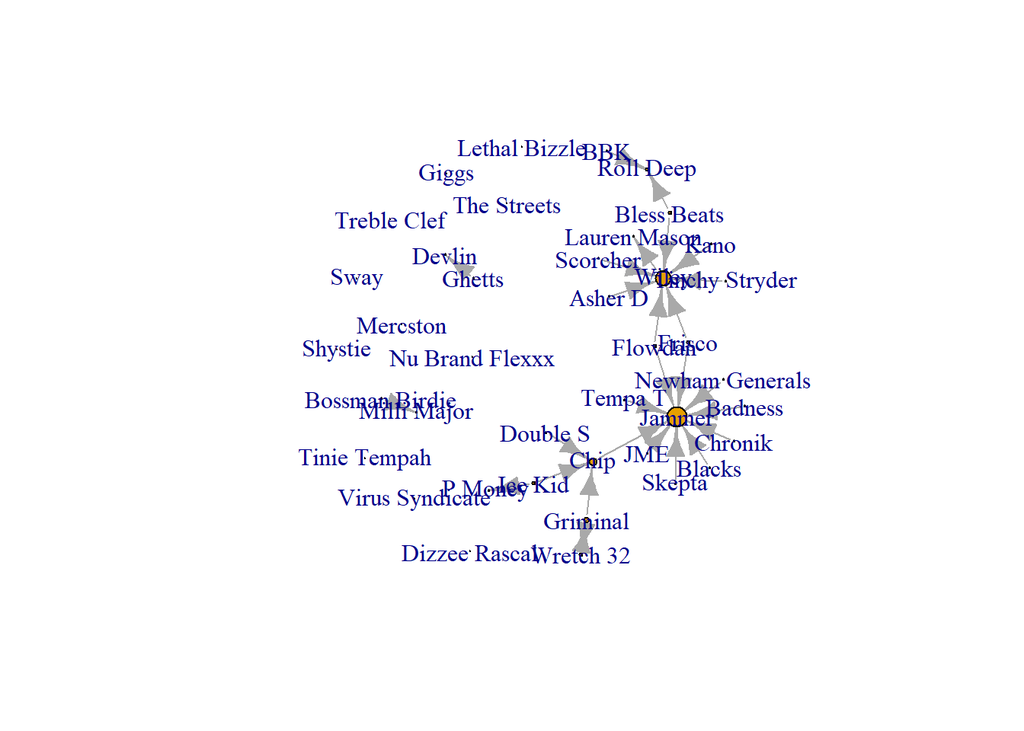

```r
plot(grime_08_clean, vertex.size = degree(grime_08_clean))
```

Pretty cool, right? Bear in mind that this literally assigned the node size to equal the value of the degree centrality. So, if a node has a degree value of 100, the their size will equal 100. This will likely crowd out other nodes in your visualisation. If this occurs, you may try dividing the degree scores by a constant (for example. 10). This will divide every node’s degree score, so the visual will still represent the relative differences between their degree. To do this simply add a division after the degree() argument. If the opposite occurs (i.e. the node’s degree centrality is too small to visualise) you can multiply it by a constant. See the examples below.

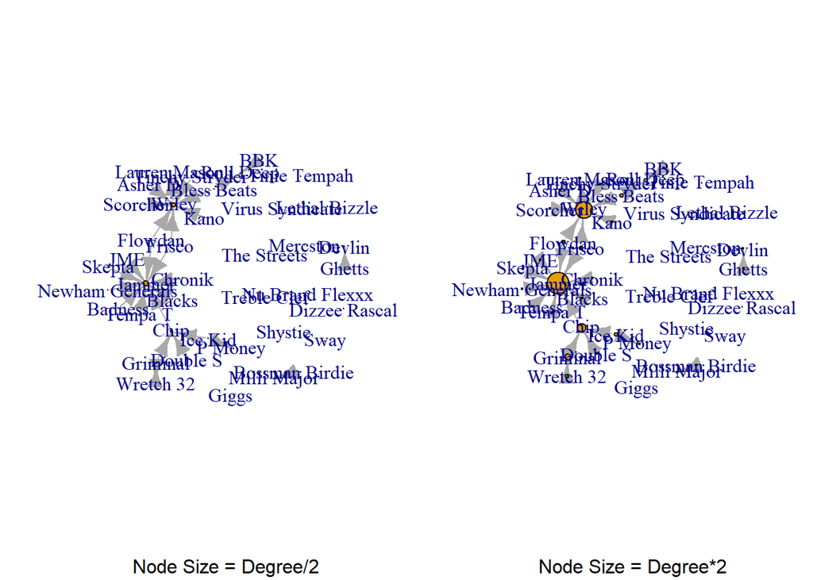

```r
par(mfrow = c(1, 2))
set.seed(123)
plot(grime_08_clean, vertex.size = degree(grime_08_clean)/2, sub = "Node Size = Degree/2")
set.seed(123)
plot(grime_08_clean, vertex.size = degree(grime_08_clean)*2, sub = "Node Size = Degree*2")
```

### Final thoughts on measures

There are many measures that you can use to tell a story about individuals in your network. They all rely on sightly different maths and algorithms. As such, I encourage you to learn, at least on a fundamental level what each measure captures so you can understant what the measure is really telling you.

Furthermore, it may make sense to remove isolates from the network and only keep the main component of the network. Depending on what measures you are using, isolates are often left out. For example, you can’t get the constraint measure for an isolate. So, you may consider only including those with connections in your analysis. This depends on what you are trying to do. I encourage you to be mindful of what you are asking and then consider if you need everyone in the network (i.e. including isolates) or if your question only involves those with connections to others.

## Tabulating Centrality Measures

We can now make this a dataframe with all the information that we have created. To do this, we need to create objects (vectors) with all of the measures we care for. Then we can assign these to a data frame that we can use.

So far, you have been just using the arguments directly and seeing them populate in the console. A good practice is to make them objects so you can use them in the future. This way, you do not have to re run the function every time. To do this, simply use the assignment operator.

```r
degree <- degree(grime_08_clean)
strength <- strength(grime_08_clean)
close <- closeness(grime_08_clean)
betweenness <- betweenness(grime_08_clean)
constraint <- constraint(grime_08_clean)
```

Note that these all create vector value objects in your environment from which you can create a table with all of these. You ca combine these into a table using the data.frame() function then list each column setting them equal to the appropriate vectors. I also create a column with the year that these data are pulled from. Finally, I name the column that lists the node names.

```r
node_data <- data.frame(
  grime_degree = degree,
  grime_strength = strength,
  grime_close = close,
  grime_constraint = constraint,
  grime_betweenness = betweenness,
  year = 2008,
  name = V(grime_08_clean)$name
)

head(node_data)
```

```
##               grime_degree grime_strength grime_close grime_constraint
## Asher D                  1              1   0.3333333              1.0
## Dizzee Rascal            0              0         NaN              NaN
## Lethal Bizzle            0              0         NaN              NaN
## Scorcher                 1              1   0.3333333              1.0
## Bless Beats              2              2   0.2500000              0.5
## Flowdan                  2              2   0.2500000              0.5
##               grime_betweenness year          name
## Asher D                       0 2008       Asher D
## Dizzee Rascal                 0 2008 Dizzee Rascal
## Lethal Bizzle                 0 2008 Lethal Bizzle
## Scorcher                      0 2008      Scorcher
## Bless Beats                   0 2008   Bless Beats
## Flowdan                       0 2008       Flowdan
```

Now, you can use your imagination on the types of things you can do with this information. What types of analyses can you think of? Maybe centrality is associated with some other attribute or variable. This network, for example, is of musicians. Perhaps centrality is associated with success, popularity, or other accolades. Perhaps, central positions are filled more by one type of artist than another (e.g. male/female, one form of music vs another). You could perform correlations, differences of means, regressions etc. The possibilities are plenty!!